# Clasificación: Regresión logísitca y árboles de decisión en R

Dr. Germán Rosati

## Introducción

Ahora que tenemos claros algunos aspectos relevantes del preprocesamiento de datos con `tidyverse`, podemos empezar a pensar en un análisis un poco más elaborado. Para ello, vamos a usar nuestro viejo y conocido dataset de delitos pero lo vamos a combinar con información censal correspondiente a los radios de la CABA.

### Objetivos

- Introducir nociones generales de modelos lineales
- Presentar las funciones en R para estimar y evaluar dichos modelos

## Preprocesando el dataset

Vamos a combinar información de los radios censales con nuestro dataset de delitos. La pregunta general que vamos a abordar es ¿podemos predecir qué radios de la CABA son peligrosos?

Traigamos todo nuestro procesamiento…

```r
radios_gral <- st_read('../data/radios_info_gral.geojson')
delitos <- read.csv('../data/delitos.csv')
delitos <- delitos %>%
        filter(latitud!=0 | longitud!=0) %>%
        mutate(fecha=ymd(fecha),
               hora=hms(hora)) %>%
        st_as_sf(
                    coords=c('longitud', 'latitud'),
                    crs=4326)
delitos_radio <- st_join(delitos,
                          radios_gral,
                          join = st_within) %>%
                as_tibble()
```

```
although coordinates are longitude/latitude, st_within assumes that they are planar
```

## Generando la variable dependiente

`` Lo que vamos a tratar de hacer es construir un modelo que nos permita clasificar a los radios censales en “peligrosos” y “no peligrosos”. Para ello vamos a construir una variable dicotómica.

```r
radios_delitos_X <- radios_delitos %>%
        mutate(peligroso = as.factor(if_else(n_delitos_hab > 0.09, 'Si', 'No'))) %>%
        select(-c(RADIO:AREA_KM2, n_dptos:std_USS_M2, n_delitos:n_delitos_hab, robo_noviol:robo_automovil)) %>%
        st_set_geometry(NULL)
```

Vemos que nuestro dataset ahora tiene una variable `peligroso`.

> ¿Cómo se construye esa variable?

A su vez, aprovechamos y limpiamos el dataset de variables redundantes y/o que no vamos a utilizar.

## Regresión logística

Sabemos que para variables dependientes binarias o categóricas el modelo lineal no suele ser recomentable

- La línea de regresión puede tomar valores negativos o mayores a 1
- Solución: usar una función logística
- En lugar de intentar predecir $E(Y|X)$ intentaremos predecir $P(Y=1|X)$
- El modelo será: $P(Y=1|X)=\frac{e^\beta_{0}+\beta_{1}X}{1+e^\beta_{0}+\beta_{1}X}$

### Implementación de una regresión logística en R: `glm()`

Para eso usaremos la función `glm()` que sirve para ajustar una gran familia de modelos llamada “Modelos Lineales Generalizados” de los cuales la regresión logística es uno de ellos.

La sintaxis de `glm()` es muy similar a la de `lm()` con la única diferencia de que debemos pasar un argumento ``family=binomial` para decirle a `R` que queremos correr una regresión logística en lugar de algún otro GLM.

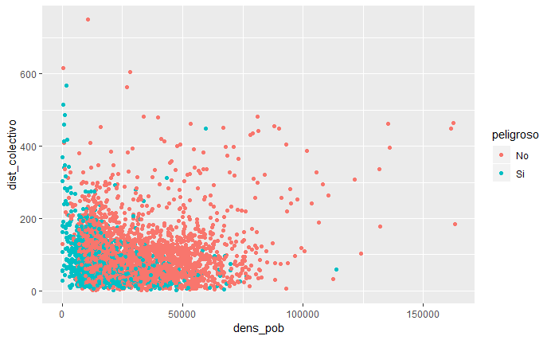

```r
ggplot(data=radios_delitos_X) +
        geom_point(aes(x=dens_pob, y=dist_colectivo, color=peligroso))
```

Pareciera que hay una cierta relación -claramente no lineal- entre ambos predictores y nuestra variable dependiente.

```r
model <- glm(peligroso~.,
             data=radios_delitos_X,
             family = binomial)
summary(model)
```

```
Call:
glm(formula = peligroso ~ ., family = binomial, data = radios_delitos_X)

Deviance Residuals:
    Min       1Q   Median       3Q      Max
-2.0651  -0.7770  -0.3920   0.7692   4.2468

Coefficients:
                           Estimate Std. Error z value Pr(>|z|)
(Intercept)               1.026e+00  8.977e-01   1.143   0.2532
tasa_desoc                1.226e-01  3.124e-02   3.925 8.68e-05 ***
tasa_act                  9.235e-03  1.120e-02   0.824   0.4097
razon_masc                5.565e-02  2.347e-01   0.237   0.8126
prop_mayores              2.790e+01  4.423e+00   6.307 2.84e-10 ***
tasa_cal_construct_insuf  1.326e-02  1.468e-02   0.903   0.3664
tasa_cal_serv_insuf       1.390e-02  1.749e-02   0.795   0.4267
tasa_cal_mat_insuf        6.550e-03  1.192e-02   0.550   0.5826
dist_bancos              -1.492e-03  2.121e-04  -7.034 2.01e-12 ***
dist_seguridad           -7.976e-04  1.183e-04  -6.743 1.55e-11 ***
dist_tren                 3.531e-04  8.454e-05   4.177 2.95e-05 ***
dist_subte               -2.011e-04  4.126e-05  -4.874 1.09e-06 ***
dist_colectivo           -5.715e-03  7.719e-04  -7.403 1.33e-13 ***
dist_metrobus            -6.167e-05  6.023e-05  -1.024   0.3059
median_USS_M2            -2.002e-04  1.080e-04  -1.854   0.0637 .
mad_USS2_M2               2.338e-04  2.573e-04   0.909   0.3636
dens_pob                 -9.703e-05  4.824e-06 -20.113  < 2e-16 ***
p_hognbi                  1.197e-02  7.842e-03   1.526   0.1269
---
Signif. codes:  0 ‘***’ 0.001 ‘**’ 0.01 ‘*’ 0.05 ‘.’ 0.1 ‘ ’ 1

(Dispersion parameter for binomial family taken to be 1)

    Null deviance: 4257.2  on 3553  degrees of freedom
Residual deviance: 3288.1  on 3536  degrees of freedom
AIC: 3324.1

Number of Fisher Scoring iterations: 6
```

Vemos que ambas variables presentan signo negativo y son significativamente diferentes a cero. Al igual que en `lm()` podemos usar la función `coef()`

```r
coef(model)
```

```
             (Intercept)               tasa_desoc
            1.025633e+00             1.226002e-01
                tasa_act               razon_masc
            9.234795e-03             5.565007e-02
            prop_mayores tasa_cal_construct_insuf
            2.789745e+01             1.325644e-02
     tasa_cal_serv_insuf       tasa_cal_mat_insuf
            1.390054e-02             6.550172e-03
             dist_bancos           dist_seguridad
           -1.492239e-03            -7.976382e-04
               dist_tren               dist_subte
            3.531040e-04            -2.011353e-04
          dist_colectivo            dist_metrobus
           -5.714671e-03            -6.167418e-05
           median_USS_M2              mad_USS2_M2
           -2.001713e-04             2.337790e-04
                dens_pob                 p_hognbi
           -9.702559e-05             1.197041e-02
```

La función `predict()` puede ser usada para generar predicciones acerca de la variable dependiente. Debemos usar el argumento ``type=response` para decirle a `R` que genere las probabilidades de que $P(Y=1|X)$ en lugar de otra información (como por ejemplo el logit)

Sabemos que esas son las probabilidades de que un radio sea considerado peligroso.

```r
model_probs<-predict(model ,type="response")
contrasts(radios_delitos_X$peligroso)
```

```
   Si
No  0
Si  1
```

```r
model_pred<-rep("No", 3554)
model_pred[model_probs>0.5]<-"Si"
#model_pred <- as.factor(model_pred)
table(radios_delitos_X$peligroso, model_pred)
```

```
    model_pred
       No   Si
  No 2321  215
  Si  570  448
```

```r
mean(model_pred == radios_delitos_X$peligroso)
```

```
[1] 0.7791221
```

La primera línea genera 3554 observaciones con el valor `No` por defecto. La segunda transforma en `Sí` a aquellas observaciones cuya `glm_probs > 0.5` Una vez armadas las predicciones podemos usar `table()` para generar una matriz de confusión de modelo. Y calculando la media de las observaciones que en `model_pred` son iguales a las de `radios_delitos_X$peligroso` (la variable dependiente original), tenemos una medida del error de clasificación del modelo.

Además, hemos estimado el error sobre TODOS nuestros datos. Lo cual nos lleva a plantearnos el problema del “Test-Error” y el “Training-Error”

(…)

## Evaluando modelos de clasificación

Entonces, ¿cómo lo implementamos en R?

```r
set.seed(102)
train <- sample(1:nrow(radios_delitos_X), nrow(radios_delitos_X)*0.7, replace=FALSE)
model <- glm(peligroso~.,
             data=radios_delitos_X,
             subset =train,
             family = binomial)
```

Luego, usamos ese vector como un índice de posición para poder hacer subsetting de `radios_delitos_X`. En tercer lugar, estimamos el mismo modelo de regresión logística pero pasando como argumento `subset = train`.

```r
glm_probs<-predict(model
           , newdata = radios_delitos_X[-train,]
           , type ="response")
glm_pred<-rep('No',1067)
glm_pred[glm_probs>0.5] <- 'Si'
conf_matrix <- table(radios_delitos_X$peligroso[-train],glm_pred)
mean(glm_pred==radios_delitos_X$peligroso[-train])
```

```
[1] 0.7591378
```

¿Qué pasa con el test error? Es más alto… No tanto… pero es para tener en cuenta.

### Precision y recall… Yendo más allá del accuracy

Existen otras métricas para evalaur un modelo de clasificación binario:

- $precision = \frac{tp}{tp + fp}$: también llamada $sensitivy$ o $true positve rate$. Evalúa sobre el total de casos clasificados como positivos por el modelo, cuántos están bien clasificados. Precision es una buena medida cuando el costo de un $fp$ es alto. Un ejemplo obvio… es detección de spam. Sería costos clasificar un mail como span si no lo fuera.
- $recall = \frac{tp}{tp + fn}$: Evalua sobre el total de casos positivos, cuántos son captados bien por el modelo. Esta métrica suele ser adeucada cuando el costso de un $fn$ es algo. En detección de fraude, clasificar a un cliente como no fraudulento cuando lo es… puede se grave.
- $f1 = 2 \times \frac{recall \times precision} {recall + precision}$: un compromiso entre ambas métricas.

```r
eval_binary <- function(conf_matrix){

        # conf_matrix tiene que tener en las filas los obervados y en las columnas los predichos. A su vez, la clase negativa tiene que ser la primera.
        #Accuracy
        acc <- (conf_matrix[1,1] + conf_matrix[2,2]) / sum(conf_matrix)

        # Precision
        prec<-conf_matrix[2,2] / (conf_matrix[2,2] + conf_matrix[1,2])

        # Recall
        recall<-conf_matrix[2,2] / (conf_matrix[2,2] + conf_matrix[2,1])
        # F1-score
        f1 <-2*(prec*recall / (prec+recall))

        return(list(accuracy=acc, precision=prec, recall=recall, f1=f1))
}
eval_binary(conf_matrix)
```

```
$`accuracy`
[1] 0.7591378

$precision
[1] 0.6092437

$recall
[1] 0.4692557

$f1
[1] 0.5301645
```

## Árbol de decisión

Usaremos la librería `tree` para construir árboles de decisión y clasificación. Vamos a trabajar con el dataset `radios_delitos_X`.

```r
library(tree)
```

Ahora usamos la función `tree` para generar un árbol de clasificación que prediga la variable nueva (dicotómica que acabamos de crear). Como vamos a ver la sintaxis de `tree()` es muy similar a la de `lm()` y `glm()`.

```r
tree_model <- tree(peligroso~.,
                   data = radios_delitos_X,
                   subset = train,
                   mindev=0.005,
                   minsize=4)
summary(tree_model)
```

```
Classification tree:
tree(formula = peligroso ~ ., data = radios_delitos_X, subset = train,
    mindev = 0.005, minsize = 4)
Variables actually used in tree construction:
[1] "dens_pob"       "dist_subte"     "dist_metrobus"  "median_USS_M2"
[5] "dist_bancos"    "p_hognbi"       "tasa_act"       "dist_colectivo"
Number of terminal nodes:  19
Residual mean deviance:  0.8222 = 2029 / 2468
Misclassification error rate: 0.1958 = 487 / 2487
```

Vemos que el Training Error es de 20%. En árboles de clasificación lo que reporta la función como “mean deviance” en el output de `summary()` es: $-2\sum_{m}\sum_{k}n_{mk}*log*\hat{p}_{mk}$

donde $n_{mk}$ es el número de observaciones en la m-ésima terminal que corresponde a la k-ésima clase. Una desviación pequeña indica un árbol que provee un buen ajuste para los datos (de entrenamiento). La residual mean deviance es implemente ese valor dividido por $n-|T_{0}|$.

Una cosa interesante y útil que proveen los árboles de decisión es que permiten tener una salida gráfica bastante útil e intuitiva del modelo. Usamos la función `plot()` para graficar la estructura y `text()` para agregarle las “etiquetas”. El argumento `pretty=0` le dice a R que muestre las categorías completas de cada cualquier predictor cualitativo.

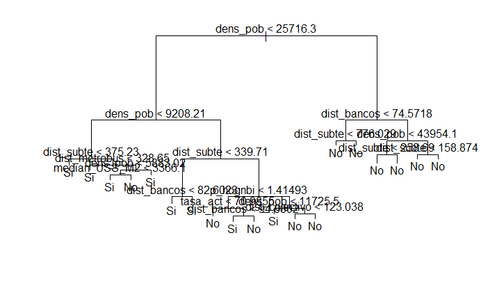

```r
plot(tree_model)
text(tree_model, pretty = 0)
```

La densidad de población y la distancia a bancos parecen ser los mejores predictores.

Si tipeamos el nombre del objeto árbol R imprime un output correspondiente a cada rama. Imprime, además, el criterio de splitting (`dens_pob` < 25716), la cantidad de observciones en esa rama, el desvío, la predicción general de la rama (`No` o `Si`) y la fracción de observaciones dentro de esa rama que toman valores `No` y `Si` . Las ramas que llegan hasta las terminales aparecen con asteriscos.

```r
tree_model
```

```
node), split, n, deviance, yval, (yprob)
      * denotes terminal node

 1) root 2487 2973.000 No ( 0.71492 0.28508 )
   2) dens_pob < 25716.3 1389 1888.000 No ( 0.58243 0.41757 )
     4) dens_pob < 9208.21 262  304.100 Si ( 0.26718 0.73282 )
       8) dist_subte < 375.23 32    0.000 Si ( 0.00000 1.00000 ) *
       9) dist_subte > 375.23 230  282.700 Si ( 0.30435 0.69565 )
        18) dist_metrobus < 328.65 43   21.760 Si ( 0.06977 0.93023 ) *
        19) dist_metrobus > 328.65 187  244.000 Si ( 0.35829 0.64171 )
          38) dens_pob < 5883.02 74   71.790 Si ( 0.18919 0.81081 )
            76) median_USS_M2 < 3366.1 67   49.010 Si ( 0.11940 0.88060 ) *
            77) median_USS_M2 > 3366.1 7    5.742 No ( 0.85714 0.14286 ) *
          39) dens_pob > 5883.02 113  156.200 Si ( 0.46903 0.53097 ) *
     5) dens_pob > 9208.21 1127 1451.000 No ( 0.65572 0.34428 )
      10) dist_subte < 339.71 178  209.500 Si ( 0.27528 0.72472 )
        20) dist_bancos < 82.6023 31    0.000 Si ( 0.00000 1.00000 ) *
        21) dist_bancos > 82.6023 147  187.100 Si ( 0.33333 0.66667 ) *
      11) dist_subte > 339.71 949 1112.000 No ( 0.72708 0.27292 )
        22) p_hognbi < 1.41493 396  356.800 No ( 0.83333 0.16667 )
          44) tasa_act < 70.9855 192  100.300 No ( 0.92708 0.07292 ) *
          45) tasa_act > 70.9855 204  231.600 No ( 0.74510 0.25490 )
            90) dist_bancos < 94.8802 10    6.502 Si ( 0.10000 0.90000 ) *
            91) dist_bancos > 94.8802 194  205.200 No ( 0.77835 0.22165 ) *
        23) p_hognbi > 1.41493 553  715.400 No ( 0.65099 0.34901 )
          46) dens_pob < 11725.5 107  147.900 Si ( 0.46729 0.53271 ) *
          47) dens_pob > 11725.5 446  548.600 No ( 0.69507 0.30493 )
            94) dist_colectivo < 123.038 331  431.200 No ( 0.64350 0.35650 ) *
            95) dist_colectivo > 123.038 115   99.790 No ( 0.84348 0.15652 ) *
   3) dens_pob > 25716.3 1098  794.700 No ( 0.88251 0.11749 )
     6) dist_bancos < 74.5718 130  172.300 No ( 0.62308 0.37692 )
      12) dist_subte < 776.029 115  156.900 No ( 0.57391 0.42609 ) *
      13) dist_subte > 776.029 15    0.000 No ( 1.00000 0.00000 ) *
     7) dist_bancos > 74.5718 968  552.100 No ( 0.91736 0.08264 )
      14) dens_pob < 43954.1 498  400.700 No ( 0.86145 0.13855 )
        28) dist_subte < 258.69 101  126.100 No ( 0.68317 0.31683 ) *
        29) dist_subte > 258.69 397  246.000 No ( 0.90680 0.09320 ) *
      15) dens_pob > 43954.1 470  104.300 No ( 0.97660 0.02340 )
        30) dist_subte < 158.874 27   25.870 No ( 0.81481 0.18519 ) *
        31) dist_subte > 158.874 443   63.540 No ( 0.98646 0.01354 ) *
```

```r
tree_preds <- predict(tree_model, radios_delitos_X[-train, ], type = "class")
conf_matrix <- table(radios_delitos_X$peligroso[-train], tree_preds)
eval_binary(conf_matrix)
```

```
$`accuracy`
[1] 0.7760075

$precision
[1] 0.6535088

$recall
[1] 0.4822006

$f1
[1] 0.5549348
```

Luego, podemos pensar en “podar” el árbol para obtener mejores resultados. la función `cv.tree()` realiza una validación cruzada para determinar el nivel óptimo de complejidad del árbol. “Cost complexity prunning” (podado basado en costo-complejidad) se usa para seleccinar una secuencia de árboles. Usamos el argumento `FUN = prune` para indicar que queremos que el error de clasificación sea el valor que se use para el proceso de podado. La función `cv.tree()` usa por defecto el desvío. A su vez, `cv.tree()` reporta la cantidad de nodos terminales en cada árbol considerado (size), así como el parámetro de costo-complejidad usado (k que se corresponde con lo que llamamos antes $\alpha$).

```r
set.seed(789)
cv_radios_delitos <- cv.tree(tree_model, K = 20, FUN = prune.misclass)
names(cv_radios_delitos)
```

```
[1] "size"   "dev"    "k"      "method"
```

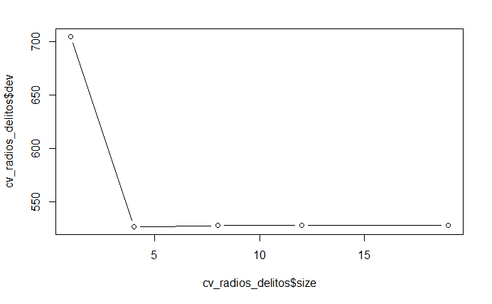

```r
# $par(mfrow=c(1,2))
plot(cv_radios_delitos$size, cv_radios_delitos$dev, type = "b")
```

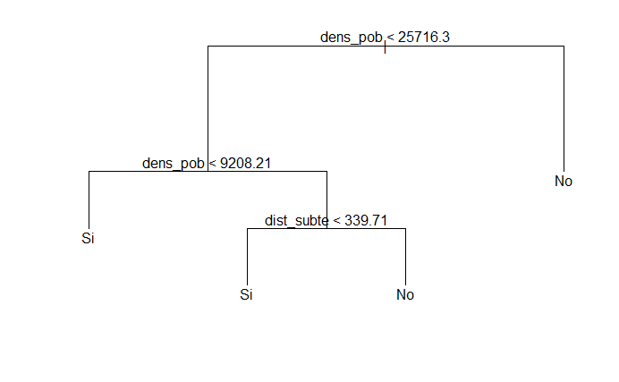

```r
prune_tree <- prune.misclass(tree_model, best = 4)
plot(prune_tree)
text(prune_tree, pretty = 0)
```

```r
prune_pred <- predict(prune_tree, radios_delitos_X[-train, ], type = "class")
conf_matrix2 <- table(radios_delitos_X$peligroso[-train], prune_pred)
eval_binary(conf_matrix2)
```

```
$`accuracy`
[1] 0.7816307

$precision
[1] 0.7043011

$recall
[1] 0.4239482

$f1
[1] 0.5292929
```

Ahora, el 78% de las observaciones están bien clasificadas. Y la mejora más importante se revela en al precision.